# Var Model - Predicting Number of Dwellings for which planning permission has been granted or an application has been made with a construction project

Piotr Wieczorek

2023-12-07

```r
rm(list=ls())
```

## Libraries

```r
library(readxl)
library(tidyverse)
library(lubridate)
library(zoo)
library(patchwork)
library(tseries)
library(forecast)
library(vars)
library(Metrics)
library(lmtest)
library(ggfortify)
```

## Reading and cleaning the data

```r
df <- read_excel('Mieszkania.xlsx')
```

### Changing colnames

```r
colnames(df) <- c("time",
"dwellings_planning_permission_granted",
"general_business_climate_index_construction",
"reference_interest_rate",
"inflation_rate"
)
```

### Variables explaination

##### dwellings_planning_permission_granted is the dependent variable

##### general_business_climate_index_construction, reference_interest_rate and inflation_rate are independent variables

```r
head(df)
```

```
## # A tibble: 6 × 5
##   time    dwellings_planning_per…¹ general_business_cli…² reference_interest_r…³
##   <chr>   <chr>                    <chr>                  <chr>
## 1 2000-1Q 24,5                     22,2                   17,50
## 2 2000-2Q 33,9                     24,2                   17,50
## 3 2000-3Q 39,4                     9,8                    19,00
## 4 2000-4Q 54,2                     -24,4                  19,00
## 5 2001-1Q 23,3                     1,9                    17,00
## 6 2001-2Q 28,7                     8,1                    15,50
## # ℹ abbreviated names: ¹dwellings_planning_permission_granted,
## #   ²general_business_climate_index_construction, ³reference_interest_rate
## # ℹ 1 more variable: inflation_rate <chr>
```

### Mutating columns

```r
df <- df %>%
  mutate(across(c(2:5),~str_replace_all(.,",","."))) %>%
  mutate(across(c(2:5),~as.numeric(.))) %>%
  mutate(inflation_rate = inflation_rate - 100)
```

```r
df <- df %>%
  mutate(time = as.factor(time))
```

```r
df$time <- zoo::as.yearqtr(df$time,format="%Y-%qQ")
```

```r
head(df)
```

```
## # A tibble: 6 × 5
##   time      dwellings_planning_p…¹ general_business_cli…² reference_interest_r…³
##   <yearqtr>                  <dbl>                  <dbl>                  <dbl>
## 1 2000 Q1                     24.5                   22.2                   17.5
## 2 2000 Q2                     33.9                   24.2                   17.5
## 3 2000 Q3                     39.4                    9.8                   19
## 4 2000 Q4                     54.2                  -24.4                   19
## 5 2001 Q1                     23.3                    1.9                   17
## 6 2001 Q2                     28.7                    8.1                   15.5
## # ℹ abbreviated names: ¹dwellings_planning_permission_granted,
## #   ²general_business_climate_index_construction, ³reference_interest_rate
## # ℹ 1 more variable: inflation_rate <dbl>
```

### Creating time series objects

```r
ts_dwellings_planning_permission_granted <- ts(df$dwellings_planning_permission_granted,start=c(2000,1),frequency = 4)
ts_general_business_climate_index_construction <- ts(df$general_business_climate_index_construction,start=c(2000,1),frequency = 4)
ts_reference_interest_rate <- ts(df$reference_interest_rate, start=c(2000,1),frequency = 4)
ts_inflation_rate <- ts(df$inflation_rate,start=c(2000,1),frequency = 4)
```

```r
th <- theme(plot.title=element_text(size=18),
            axis.title.x = element_text(size=16),
            axis.title.y = element_text(size=16),
            axis.text.x = element_text(size=14),
            axis.text.y = element_text(size=14),
            legend.title = element_text(size=18),
            legend.text = element_text(size=14))
```

## Exploratory analysis

### Plotting the data

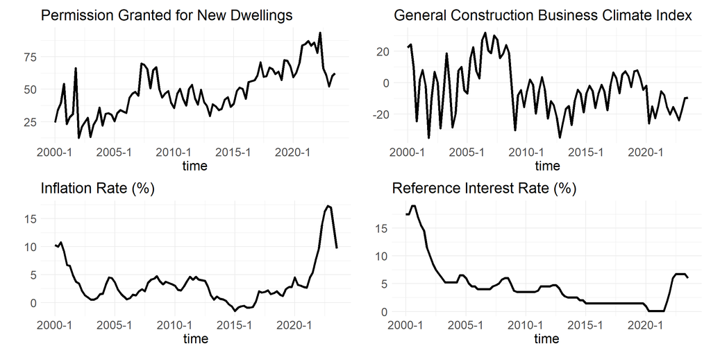

```r
p1 <- df %>%
  ggplot(aes(x=time,y=dwellings_planning_permission_granted)) +
  geom_line(lwd=1.4)+ labs(y="",title="Permission Granted for New Dwellings") + theme_minimal()  + th



p2 <- df %>%
  ggplot(aes(x=time,y=general_business_climate_index_construction))  +
  geom_line(lwd=1.4) +  labs(y="",title="General Construction Business Climate Index") + theme_minimal()+ th

p3<- df %>%
  ggplot(aes(x=time , y = inflation_rate)) +
  geom_line(lwd=1.4) + labs(y="",title = "Inflation Rate (%)") + theme_minimal() +  th

p4<- df %>%
  ggplot(aes(x=time , y = reference_interest_rate)) +
  geom_line(lwd=1.4) + labs(y="",title = "Reference Interest Rate (%)") + theme_minimal() +  th

(p1+p2)/(p3+p4)
```

### ADF tests

##### All of the variables needed to be differenced of the first order in order to become stationary

```r
adf_dwellings <- adf.test(ts_dwellings_planning_permission_granted)
adf_construction <- adf.test(ts_general_business_climate_index_construction)
adf_inflation <- adf.test(ts_inflation_rate)
adf_reference_interest_rate <- adf.test(ts_reference_interest_rate)

adf_dwellings_diff <- adf.test(diff(ts_dwellings_planning_permission_granted))
adf_construction_diff <- adf.test(diff(ts_general_business_climate_index_construction))
adf_inflation_diff <- adf.test(diff(ts_inflation_rate))
adf_reference_interest_rate_diff <- adf.test(diff(ts_reference_interest_rate))
```

```r
adf_tests_data <- data.frame(DickeyFuller = numeric(),
                             p_value = numeric(),
                             variable_name = character(),
                             stringsAsFactors = FALSE)


adf_list <- list(adf_dwellings,
                 adf_construction,
                 adf_inflation,
                 adf_reference_interest_rate,
                 adf_dwellings_diff,
                 adf_construction_diff,
                 adf_inflation_diff,
                 adf_reference_interest_rate_diff)


variable_names <- c("adf_dwellings",
                    "adf_construction",
                    "adf_inflation",
                    "adf_reference_interest_rate",
                    "adf_dwellings_diff",
                    "adf_construction_diff",
                    "adf_inflation_diff",
                    "adf_reference_interest_rate_diff")


for (i in seq_along(adf_list)) {
    test_result <- adf_list[[i]]
    DickeyFuller <- test_result$statistic
    p_value <- round(test_result$p.value,4)
    variable_name <- variable_names[i]


    output <- data.frame(DickeyFuller = DickeyFuller,
                         p_value = p_value,
                         variable_name = variable_name,
                         stringsAsFactors = FALSE)


    adf_tests_data <- rbind(adf_tests_data, output)
}

print(adf_tests_data)
```

```
##                DickeyFuller p_value                    variable_name
## Dickey-Fuller     -2.844158  0.2278                    adf_dwellings
## Dickey-Fuller1    -3.089092  0.1266                 adf_construction
## Dickey-Fuller2    -1.890162  0.6218                    adf_inflation
## Dickey-Fuller3    -3.440705  0.0525      adf_reference_interest_rate
## Dickey-Fuller4    -3.560231  0.0409               adf_dwellings_diff
## Dickey-Fuller5    -4.190509  0.0100            adf_construction_diff
## Dickey-Fuller6    -4.581789  0.0100               adf_inflation_diff
## Dickey-Fuller7    -4.386728  0.0100 adf_reference_interest_rate_diff
```

## Modeling

### Binding times series data by columns

```r
ts_dwellings_diff <- diff(ts_dwellings_planning_permission_granted)
ts_construction_diff <- diff(ts_general_business_climate_index_construction)
ts_inflation_diff <- diff(ts_inflation_rate)
ts_reference_rate_diff <- diff(ts_reference_interest_rate)
```

```r
df2 <- cbind(ts_dwellings_diff,ts_construction_diff,ts_inflation_diff,ts_reference_rate_diff)
```

```r
df2
```

```
##         ts_dwellings_diff ts_construction_diff ts_inflation_diff
## 2000 Q2               9.4                  2.0              -0.3
## 2000 Q3               5.5                -14.4               0.8
## 2000 Q4              14.8                -34.2              -1.6
## 2001 Q1             -30.9                 26.3              -2.5
## 2001 Q2               5.4                  6.2              -0.1
## 2001 Q3               2.1                -10.0              -1.7
## 2001 Q4              35.4                -33.2              -1.2
## 2002 Q1             -53.7                 25.1              -0.3
## 2002 Q2               8.7                 16.8              -1.3
## 2002 Q3               3.2                 -6.9              -0.8
## 2002 Q4               3.5                -28.9              -0.4
## 2003 Q1             -14.7                 22.6              -0.4
## 2003 Q2               9.7                 24.9               0.0
## 2003 Q3               4.0                -18.1               0.3
```

[output cut: 175 more lines]

### Selecting optimal lag for the model

```r
VARselect(df2,lag.max = 4)
```

```
## $selection
## AIC(n)  HQ(n)  SC(n) FPE(n)
##      4      4      4      4
##
## $criteria
##                  1           2           3          4
## AIC(n)    7.796428    7.286100    6.982311   6.335596
## HQ(n)     8.020444    7.689328    7.564751   7.097249
## SC(n)     8.351942    8.286024    8.426645   8.224341
## FPE(n) 2433.015066 1463.788012 1086.209333 574.765768
```

### Model formula

```r
estim <- VAR(df2,p=4,type="const")
```

### Summary

##### The model captures ~58% of the variance of differenced dwellings permissions

```r
summary(estim$varresult$ts_dwellings_diff)
```

```
##
## Call:
## lm(formula = y ~ -1 + ., data = datamat)
##
## Residuals:
##      Min       1Q   Median       3Q      Max
## -14.2562  -4.0350  -0.0931   3.2460  19.6270
##
## Coefficients:
##                           Estimate Std. Error t value Pr(>|t|)
## ts_dwellings_diff.l1      -0.28683    0.10412  -2.755 0.007407 **
## ts_construction_diff.l1    0.20079    0.09157   2.193 0.031518 *
## ts_inflation_diff.l1      -2.90202    1.03322  -2.809 0.006378 **
## ts_reference_rate_diff.l1  5.34540    1.85974   2.874 0.005302 **
## ts_dwellings_diff.l2      -0.18830    0.10464  -1.800 0.076066 .
## ts_construction_diff.l2   -0.06696    0.08925  -0.750 0.455519
## ts_inflation_diff.l2      -0.25877    1.24853  -0.207 0.836385
## ts_reference_rate_diff.l2  0.60444    2.13490   0.283 0.777882
## ts_dwellings_diff.l3      -0.08128    0.10585  -0.768 0.445033
## ts_construction_diff.l3    0.14041    0.08798   1.596 0.114805
## ts_inflation_diff.l3      -2.64527    1.23418  -2.143 0.035418 *
## ts_reference_rate_diff.l3 -4.68813    2.10583  -2.226 0.029083 *
## ts_dwellings_diff.l4       0.38730    0.09567   4.048 0.000127 ***
## ts_construction_diff.l4    0.05042    0.08647   0.583 0.561637
## ts_inflation_diff.l4       0.83740    1.25138   0.669 0.505491
## ts_reference_rate_diff.l4  3.24092    1.75839   1.843 0.069372 .
## const                      1.30907    0.87696   1.493 0.139816
## ---
## Signif. codes:  0 '***' 0.001 '**' 0.01 '*' 0.05 '.' 0.1 ' ' 1
##
## Residual standard error: 6.931 on 73 degrees of freedom
## Multiple R-squared:  0.6534, Adjusted R-squared:  0.5775
## F-statistic: 8.603 on 16 and 73 DF,  p-value: 3.155e-11
```

### Casuality tests

##### The grangertest from the lmtest library is essentially a Wald test for nested models.

##### It checks, whether or not an autoregressive model, where the dependent variable is regressed on its past values is worse than a model where the dependent variable is regressed on its past values and past values of the other variable

##### Pr(>F) < 0.1 implies that there is statistical evidence to support the idea that past values of differenced inflation rate Granger cause differenced dwellings permissions

```r
lmtest::grangertest(ts_dwellings_diff~ts_inflation_diff,order=4)
```

```
## Granger causality test
##
## Model 1: ts_dwellings_diff ~ Lags(ts_dwellings_diff, 1:4) + Lags(ts_inflation_diff, 1:4)
## Model 2: ts_dwellings_diff ~ Lags(ts_dwellings_diff, 1:4)
##   Res.Df Df      F   Pr(>F)
## 1     81
## 2     85 -4 4.0875 0.004552 **
## ---
## Signif. codes:  0 '***' 0.001 '**' 0.01 '*' 0.05 '.' 0.1 ' ' 1
```

##### Pr(>F) < 0.1 implies that there is statistical evidence to support the idea that past values of differenced construction climate index Granger cause differenced dwellings permissions

```r
lmtest::grangertest(ts_dwellings_diff~ts_construction_diff,order=4)
```

```
## Granger causality test
##
## Model 1: ts_dwellings_diff ~ Lags(ts_dwellings_diff, 1:4) + Lags(ts_construction_diff, 1:4)
## Model 2: ts_dwellings_diff ~ Lags(ts_dwellings_diff, 1:4)
##   Res.Df Df      F  Pr(>F)
## 1     81
## 2     85 -4 2.0302 0.09789 .
## ---
## Signif. codes:  0 '***' 0.001 '**' 0.01 '*' 0.05 '.' 0.1 ' ' 1
```

##### Pr(>F) < 0.1 implies that there is statistical evidence to support the idea that past values of differenced reference rate Granger cause differenced dwellings permissions

```r
lmtest::grangertest(ts_dwellings_diff~ts_reference_rate_diff,order=4)
```

```
## Granger causality test
##
## Model 1: ts_dwellings_diff ~ Lags(ts_dwellings_diff, 1:4) + Lags(ts_reference_rate_diff, 1:4)
## Model 2: ts_dwellings_diff ~ Lags(ts_dwellings_diff, 1:4)
##   Res.Df Df      F   Pr(>F)
## 1     81
## 2     85 -4 4.9701 0.001238 **
## ---
## Signif. codes:  0 '***' 0.001 '**' 0.01 '*' 0.05 '.' 0.1 ' ' 1
```

### Forecast error variance decomposition

##### Both differenced inflation rate and difference construction climate index have an impact on explaining forecast error of the differenced dwellings permissions variable. It increases with time, which is typical for variance decomposition

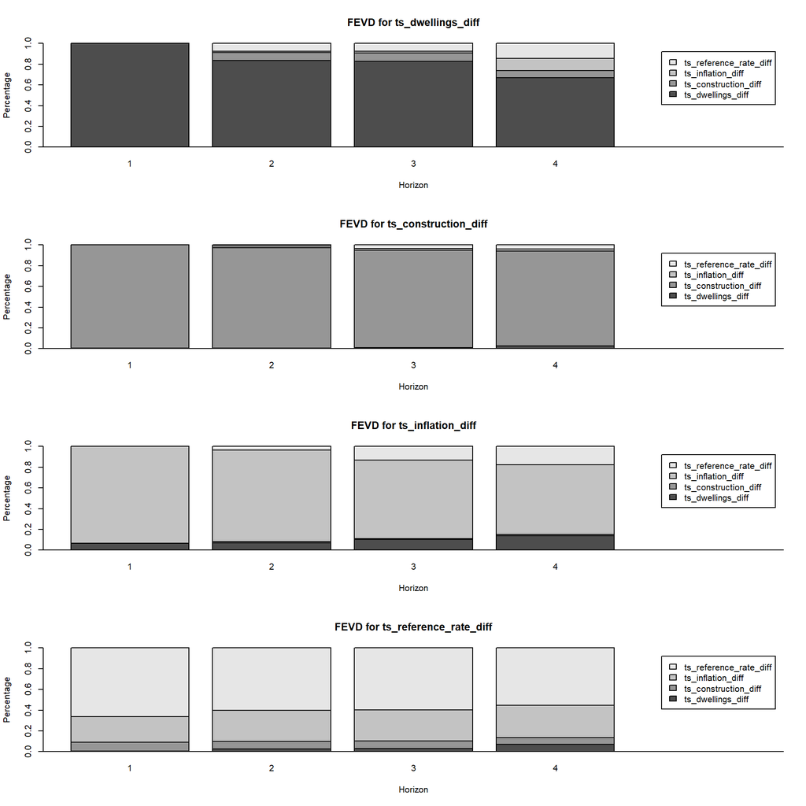

```r
plot(fevd(estim, n.ahead =4))
```

### Impulse response function

##### There is a statistically signifcant decrease of differenced dwellings permissions as a reaction to the sudden (positive) shock in differenced inflation rate around the 4th quarter after the signal

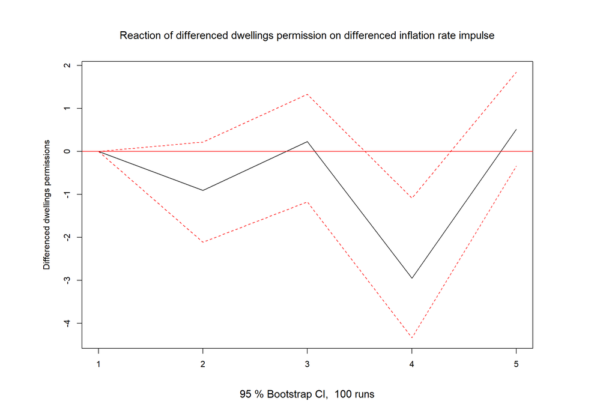

```r
set.seed(123)

plot(irf(estim,impulse="ts_inflation_diff",response = "ts_dwellings_diff",n.ahead = 4),main="Reaction of differenced dwellings permission on differenced inflation rate impulse",cex=1.25,ylab="Differenced dwellings permissions")
```

##### There is a statistically signifcant increase of differenced dwellings permissions as a reaction to the sudden (positive) shock in differenced construction climate index between the first and the second quarter after the signal occured

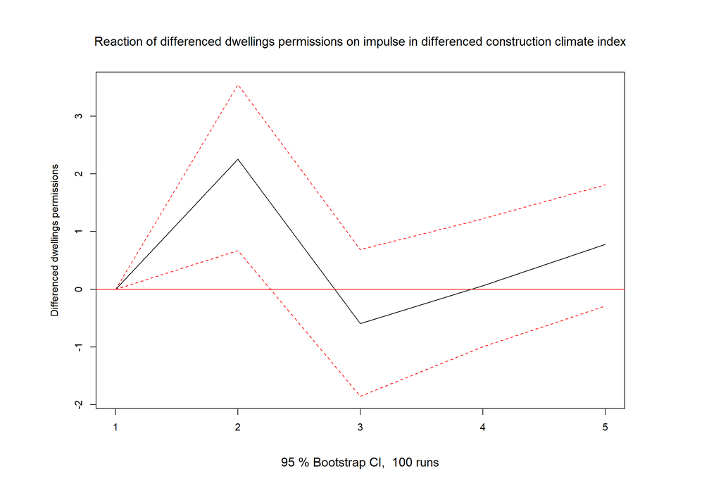

```r
set.seed(123)

plot(irf(estim,impulse="ts_construction_diff",response = "ts_dwellings_diff",n.ahead = 4),main="Reaction of differenced dwellings permissions on impulse in differenced construction climate index",cex=1.25, ylab="Differenced dwellings permissions")
```

##### There is a statistically signifcant increase of differenced dwellings permissions as a reaction to the sudden (positive) shock in differenced reference rate between the first and the second quarter after the signal occured and also a statistically significant decrease around the fourth quarter after the signal occured

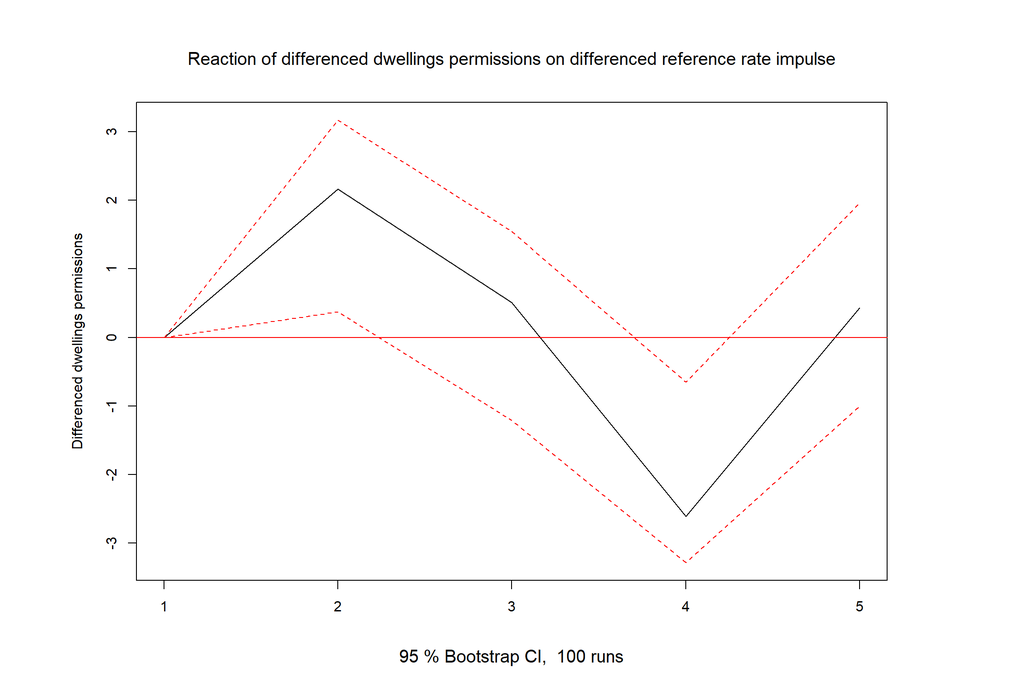

```r
set.seed(123)

plot(irf(estim,impulse="ts_reference_rate_diff",response = "ts_dwellings_diff",n.ahead = 4),main="Reaction of differenced dwellings permissions on differenced reference rate impulse",cex=1.25,ylab="Differenced dwellings permissions")
```

### Prediction for the next 4 periods

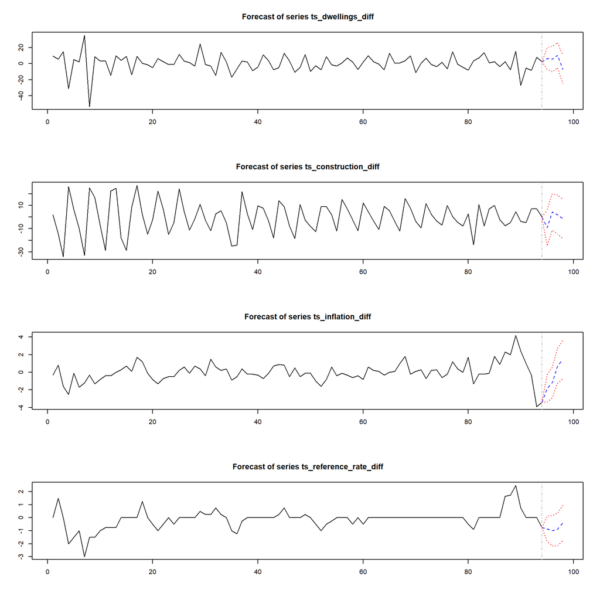

```r
plot(predict(estim,n.ahead = 4))
```

```r
forecast(estim,h=4)
```

```
## ts_dwellings_diff
##         Point Forecast         Lo 80     Hi 80      Lo 95    Hi 95
## 2023 Q4       6.498934  -2.383136528 15.381005  -7.085021 20.08289
## 2024 Q1       5.722091  -4.526273467 15.970455  -9.951430 21.39561
## 2024 Q2      10.339410   0.003848311 20.674972  -5.467468 26.14629
## 2024 Q3      -7.238903 -18.801644013  4.323838 -24.922589 10.44478
##
## ts_construction_diff
##         Point Forecast     Lo 80      Hi 80     Lo 95     Hi 95
## 2023 Q4      -9.144817 -19.25286  0.9632221 -24.60373  6.314095
## 2024 Q1       4.355602  -5.91473 14.6259328 -11.35151 20.062718
## 2024 Q2       2.104169  -8.90739 13.1157282 -14.73656 18.944896
## 2024 Q3      -1.539273 -12.71993  9.6413832 -18.63861 15.560065
##
## ts_inflation_diff
##         Point Forecast       Lo 80       Hi 80      Lo 95      Hi 95
## 2023 Q4     -1.8020974 -2.82111084 -0.78308388 -3.3605440 -0.2436507
## 2024 Q1     -1.1515407 -2.28123802 -0.02184345 -2.8792636  0.5761822
## 2024 Q2      0.7445726 -0.54366390  2.03280905 -1.2256151  2.7147602
## 2024 Q3      1.4617961  0.04886095  2.87473130 -0.6991018  3.6226940
##
## ts_reference_rate_diff
##         Point Forecast     Lo 80       Hi 80     Lo 95     Hi 95
## 2023 Q4     -0.8481895 -1.485551 -0.21082797 -1.822950 0.1265709
## 2024 Q1     -1.0077417 -1.772444 -0.24303923 -2.177253 0.1617698
## 2024 Q2     -0.8898732 -1.718908 -0.06083818 -2.157773 0.3780265
## 2024 Q3     -0.3966110 -1.277722  0.48450039 -1.744155 0.9509326
```

### Residuals diagnostics

```r
var_residuals <- as.data.frame(estim[["varresult"]][["ts_dwellings_diff"]][["residuals"]])
colnames(var_residuals)[1] <- "residuals"
```

##### Although the histogram and QQ-plot could indicate that the variable is not normally distributed, p-value from the shapiro-wilk test amounts to 0.4071

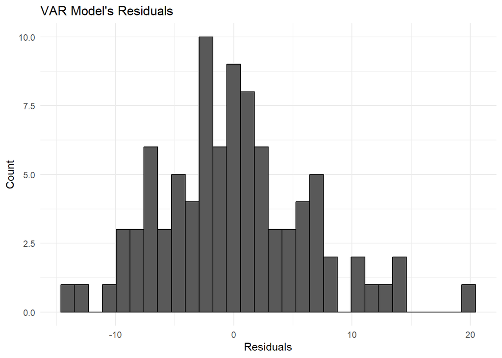

```r
var_residuals %>%
  ggplot(aes(x=residuals)) +
  geom_histogram(color="black") +
  labs(y="Count",x="Residuals",title="VAR Model's Residuals") +
  theme_minimal()
```

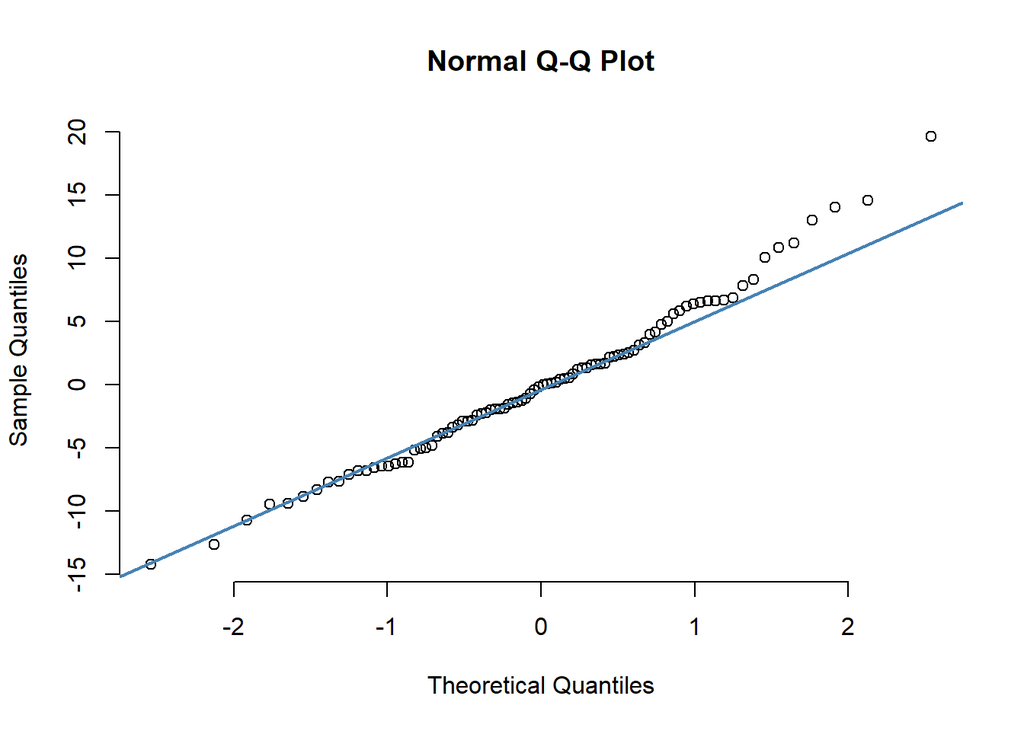

```r
qqnorm(var_residuals$residuals, pch = 1, frame = FALSE)
qqline(var_residuals$residuals, col = "steelblue", lwd = 2)
```

```r
shapiro.test(var_residuals$residuals)
```

```
##
##  Shapiro-Wilk normality test
##
## data:  var_residuals$residuals
## W = 0.98529, p-value = 0.4071
```

#### Residuals autocorrelation

##### Based on the ACF Plot and Ljung-Box test, there is a strong evidence that there is no autocorrelation in the residuals

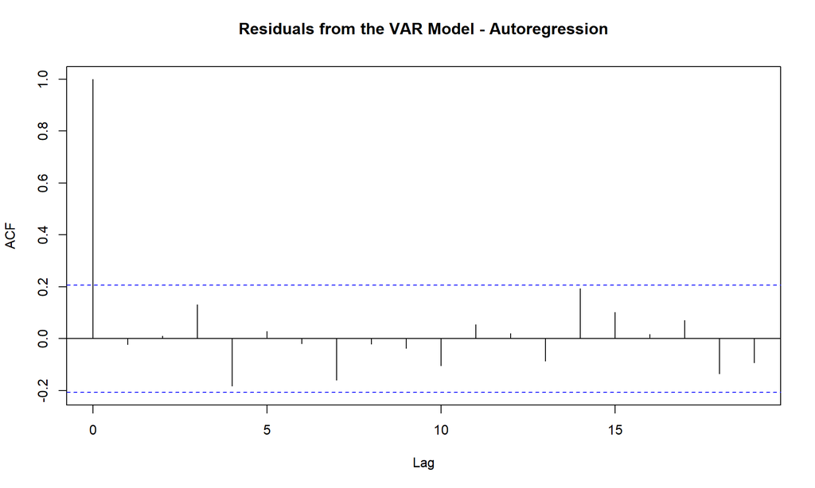

```r
acf(var_residuals$residuals,main="Residuals from the VAR Model - Autoregression")
```

```r
stats::Box.test(estim[["varresult"]][["ts_dwellings_diff"]][["residuals"]],
                type="Ljung-Box",lag = 4)
```

```
##
##  Box-Ljung test
##
## data:  estim[["varresult"]][["ts_dwellings_diff"]][["residuals"]]
## X-squared = 4.875, df = 4, p-value = 0.3004
```

```r
var_forecast <- forecast(estim,h=4)
```

```r
var_forecast[['forecast']][['ts_dwellings_diff']]
```

```
##         Point Forecast         Lo 80     Hi 80      Lo 95    Hi 95
## 2023 Q4       6.498934  -2.383136528 15.381005  -7.085021 20.08289
## 2024 Q1       5.722091  -4.526273467 15.970455  -9.951430 21.39561
## 2024 Q2      10.339410   0.003848311 20.674972  -5.467468 26.14629
## 2024 Q3      -7.238903 -18.801644013  4.323838 -24.922589 10.44478
```

### VAR Model Fitting the data

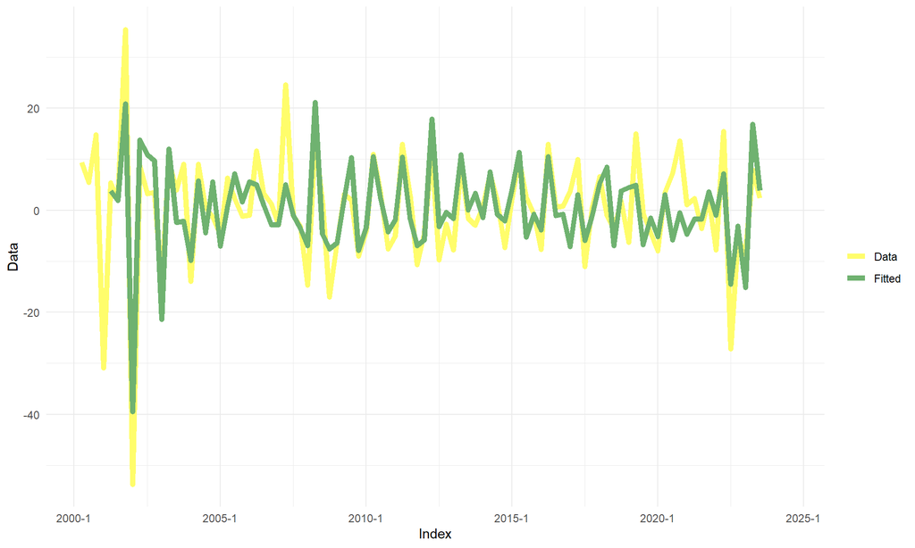

```r
fortify(var_forecast[["forecast"]][["ts_dwellings_diff"]]) %>%
  mutate(Index = as.yearqtr(Index)) %>%
  ggplot(aes(x=Index)) +
  geom_line(aes(y=Data,color="Data"),linewidth=2)+
  geom_line(aes(y=Fitted,color="Fitted"),linewidth=2) +
  scale_color_manual(name = "",
                     values = c("Data" = "#FFFD6B","Fitted" = "#6FB270"),
                     breaks=c("Data","Fitted")) +
  theme_minimal()
```